# Running estimate_cycle_position from tricycle on Seurat Objects

Compiled: July 09, 2021

This vignette demonstrates the use of the estimate_cycle_position from the tricycle package on Seurat objects.

> *Universal prediction of cell cycle position using transfer learning*

> Shijie C. Zheng, Genevieve Stein-O’Brien, Jonathan J. Augustin, Jared Slosberg, Giovanni A. Carosso, Briana Winer, Gloria Shin, Hans T. Bjornsson, Loyal A. Goff, Kasper D. Hansen

> bioRxiv, 2021.

> doi: 10.1101/2021.04.06.438463

> Bioconductor: https://www.bioconductor.org/packages/release/bioc/html/tricycle.html

Prerequisites to install:

- [Seurat](https://satijalab.org/seurat/install)
- [SeuratWrappers](https://github.com/satijalab/seurat-wrappers)
- [tricycle](https://www.bioconductor.org/packages/release/bioc/html/tricycle.html)

```r
library(Seurat)
library(SeuratWrappers)
library(tricycle)
```

## Introduction

The Biocondutor package [tricycle](https://www.bioconductor.org/packages/release/bioc/html/tricycle.html) infers cell cycle position for a single-cell RNA-seq dataset. Here, we show the implementation of **main** function of tricycle, estimate_cycle_position, on the Seurat objects. More information can be found at [tricycle](https://www.bioconductor.org/packages/release/bioc/html/tricycle.html).

## Loading examle data and making Seurat object

```r
data(neurosphere_example, package = "tricycle")
neurosphere_example <- as.Seurat(neurosphere_example)
neurosphere_example
```

```
## An object of class Seurat
## 1500 features across 400 samples within 1 assay
## Active assay: RNA (1500 features, 0 variable features)
```

Note that after converting the SingleCellExperiment object to Seurat object, the original “logcounts” assay is saved as a slot with name “data” in Seurat default Assay.

## Inferring the cell cycle position

The `Runtricycle()` function in the SeuratWrappers package first project the data into the cell cycle embeddings using the internal reference in tricycle package, and then estimate the cell cycle position. The estimated cell cycle position is bound between 0 and 2pi. Note that we strive to get high resolution of cell cycle state, and we think the continuous position is more appropriate when describing the cell cycle. However, to help users understand the position variable, we also note that users can approximately relate 0.5pi to be the start of S stage, pi to be the start of G2M stage, 1.5pi to be the middle of M stage, and 1.75pi-0.25pi to be G1/G0 stage.

```r
neurosphere_example <- Runtricycle(object = neurosphere_example, slot = "data", reduction.name = "tricycleEmbedding",
    reduction.key = "tricycleEmbedding_", gname = NULL, gname.type = "ENSEMBL", species = "mouse")
```

## Visualizing the results

We could extract the cell cycle embedding and make a scatter plot of the embeddings colored by the position inference. And we also extract the expression level of gene Top2a for accessing the performance, described below.

```r
plot.df <- FetchData(object = neurosphere_example, vars = c("tricycleEmbedding_1", "tricycleEmbedding_2",
    "tricyclePosition", "ENSMUSG00000020914"))
names(plot.df)[4] <- "Top2a"
```

Let us plot out the cell cycle embedding. You could also plot other embeddings, such as T_SNE or UMAP with points colored by the cell cycle position.

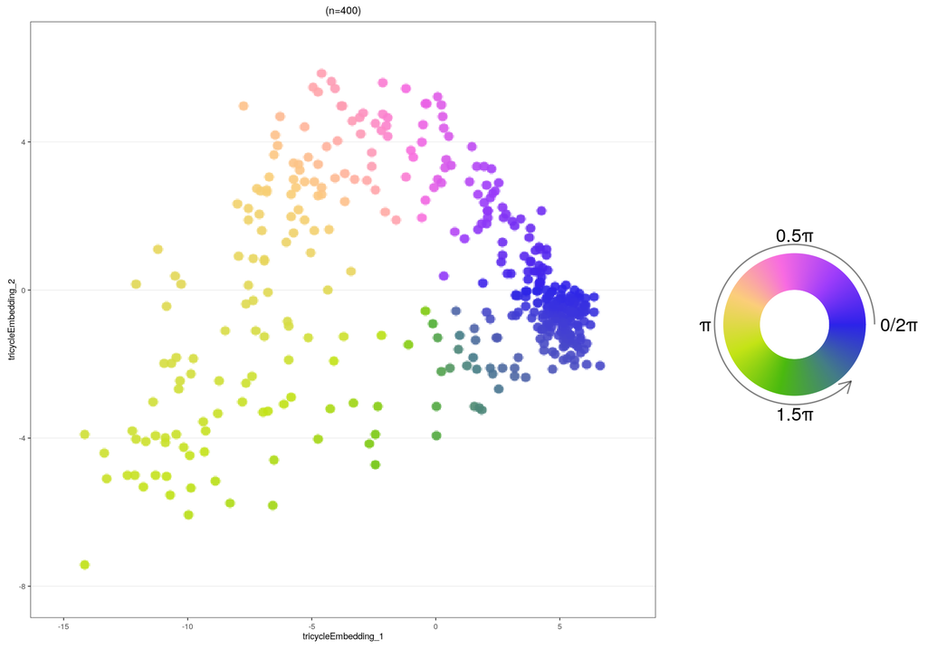

```r
library(ggplot2)
library(cowplot)
p <- tricycle:::.plot_emb_circle_scale(emb.m = plot.df[, 1:2], color.value = plot.df$tricyclePosition,
    color_by = "tricyclePosition", point.size = 3.5, point.alpha = 0.9)
legend <- circle_scale_legend(text.size = 5, alpha = 0.9)
plot_grid(p, legend, ncol = 2, rel_widths = c(1, 0.4))
```

## Assessing performance

We have two ways of (quickly) assessing whether triCycle works. They are

1. Look at the projection of the data into the cell cycle embedding.
2. Look at the expression of key genes as a function of cell cycle position.

Plotting the projection of the data into the cell cycle embedding is shown above. Our observation is that deeper sequenced data will have a more clearly ellipsoid pattern with an empty interior. As sequencing depth decreases, the radius of the ellipsoid decreases until the empty interior disappears. So the absence of an interior does not mean the method does not work.

It is more important to inspect a couple of genes as a function of cell cycle position. We tend to use Top2a which is highly expressed and therefore “plottable” in every dataset. Other candidates are for example Smc2. To plot this data, we provide a convenient function `fit_periodic_loess()` to fit a loess line between the cyclic variable $\theta$ and other response variables. This fitting is done by making `theta.v` 3 periods `(c(theta.v - 2 * pi, theta.v, theta.v + 2 * pi))` and repeating `y` 3 times. Only the fitted values corresponding to original `theta.v` will be returned. In this example, we show how well the expression of the cell cycle marker gene *Top2a* change along $\theta$.

```r
fit.l <- fit_periodic_loess(neurosphere_example$tricyclePosition, plot.df$Top2a, plot = TRUE, x_lab = "Cell cycle position θ",
    y_lab = "log2(Top2a)", fig.title = paste0("Expression of Top2a along θ (n=", ncol(neurosphere_example),
        ")"))
names(fit.l)
```

```
## [1] "fitted"   "residual" "pred.df"  "loess.o"  "rsquared" "fig"
```

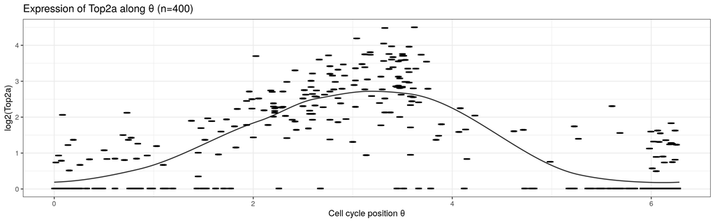

```r
fit.l$fig + theme_bw(base_size = 14)
```

For Top2a we expect peak expression around $\pi$.

## Plot out the kernel density

Another useful function is *plot_ccposition_den*, which computes kernel density of $\theta$ conditioned on a phenotype using von Mises distribution. The ouput figures are provided in two flavors, polar coordinates and Cartesian coordinates. This could be useful when comparing different cell types, treatments, or just stages. (Because we use a very small dataset here as example, we set the bandwith, i.e. the concentration parameter of the von Mises distribution as 10 to get a smooth line.)

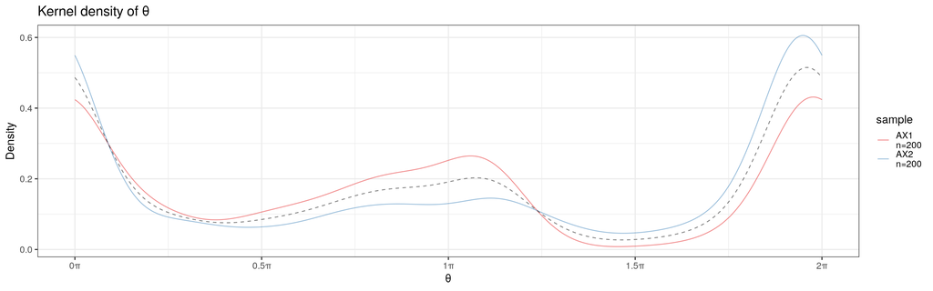

```r
plot_ccposition_den(neurosphere_example$tricyclePosition, neurosphere_example$sample, "sample",
    bw = 10, fig.title = "Kernel density of θ") + theme_bw(base_size = 14)
```

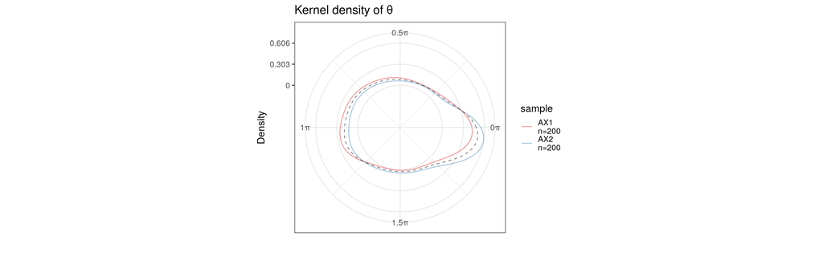

```r
plot_ccposition_den(neurosphere_example$tricyclePosition, neurosphere_example$sample, "sample",
    type = "circular", bw = 10, fig.title = "Kernel density of θ") + theme_bw(base_size = 14)
```

## Resoures for tricycle

More information about constructing your own reference, other usages and running tricycle outside of the Seurat environment can be found at [tricycle](https://www.bioconductor.org/packages/release/bioc/html/tricycle.html).